# R Notebook

This is my first R Project, i want to use the knowledge of Time Series Analysis to Evaluate and forecast the rate of covid-19 cases in Nigeria by the end of december 2020 using the Prophet Packages in R. My data was pulled from https://ourworldindata.org/coronavirus-source-data The data on the coronavirus pandemic is updated daily. Last update: November 3, 2020 (10:30, London time).

Reading the data file from my document into Covid19 variable

lets check out the data set

|  | iso_code | continent | location | date | total_cases | new_cases | new_cases_smoothed | total_deaths | new_deaths | new_deaths_smoothed | total_cases_per_million | new_cases_per_million | new_cases_smoothed_per_million | total_deaths_per_million | new_deaths_per_million | new_deaths_smoothed_per_million | icu_patients | icu_patients_per_million | hosp_patients | hosp_patients_per_million | weekly_icu_admissions | weekly_icu_admissions_per_million | weekly_hosp_admissions | weekly_hosp_admissions_per_million | total_tests | new_tests | total_tests_per_thousand | new_tests_per_thousand | new_tests_smoothed | … |
| --- | --- | --- | --- | --- | --- | --- | --- | --- | --- | --- | --- | --- | --- | --- | --- | --- | --- | --- | --- | --- | --- | --- | --- | --- | --- | --- | --- | --- | --- | --- |
| 1 | ABW | North America | Aruba | 2020-03-13 | 2 | 2 | NA | NA | 0 | NA | 18.733 | 18.733 | NA | NA | 0 | NA | NA | NA | NA | NA | NA | NA | NA | NA | NA | NA | NA | NA | NA | … |
| 2 | ABW | North America | Aruba | 2020-03-19 | NA | NA | 0.286 | NA | NA | 0 | NA | NA | 2.676 | NA | NA | 0 | NA | NA | NA | NA | NA | NA | NA | NA | NA | NA | NA | NA | NA | … |
| 3 | ABW | North America | Aruba | 2020-03-20 | 4 | 2 | 0.286 | NA | 0 | 0 | 37.465 | 18.733 | 2.676 | NA | 0 | 0 | NA | NA | NA | NA | NA | NA | NA | NA | NA | NA | NA | NA | NA | … |
| 4 | ABW | North America | Aruba | 2020-03-21 | NA | NA | 0.286 | NA | NA | 0 | NA | NA | 2.676 | NA | NA | 0 | NA | NA | NA | NA | NA | NA | NA | NA | NA | NA | NA | NA | NA | … |
| 5 | ABW | North America | Aruba | 2020-03-22 | NA | NA | 0.286 | NA | NA | 0 | NA | NA | 2.676 | NA | NA | 0 | NA | NA | NA | NA | NA | NA | NA | NA | NA | NA | NA | NA | NA | … |
| 6 | ABW | North America | Aruba | 2020-03-23 | NA | NA | 0.286 | NA | NA | 0 | NA | NA | 2.676 | NA | NA | 0 | NA | NA | NA | NA | NA | NA | NA | NA | NA | NA | NA | NA | NA | … |
| 7 | ABW | North America | Aruba | 2020-03-24 | 12 | 8 | 1.429 | NA | 0 | 0 | 112.395 | 74.930 | 13.380 | NA | 0 | 0 | NA | NA | NA | NA | NA | NA | NA | NA | NA | NA | NA | NA | NA | … |
| 8 | ABW | North America | Aruba | 2020-03-25 | 17 | 5 | 2.143 | NA | 0 | 0 | 159.227 | 46.831 | 20.071 | NA | 0 | 0 | NA | NA | NA | NA | NA | NA | NA | NA | NA | NA | NA | NA | NA | … |
| 9 | ABW | North America | Aruba | 2020-03-26 | 19 | 2 | 2.429 | NA | 0 | 0 | 177.959 | 18.733 | 22.747 | NA | 0 | 0 | NA | NA | NA | NA | NA | NA | NA | NA | NA | NA | NA | NA | NA | … |
| 10 | ABW | North America | Aruba | 2020-03-27 | 28 | 9 | 3.429 | NA | 0 | 0 | 262.256 | 84.296 | 32.113 | NA | 0 | 0 | NA | NA | NA | NA | NA | NA | NA | NA | NA | NA | NA | NA | NA | … |

I want to try and get the column names

```r
colnames(covid19)
```

```
 [1] "iso_code"                           "continent"
 [3] "location"                           "date"
 [5] "total_cases"                        "new_cases"
 [7] "new_cases_smoothed"                 "total_deaths"
 [9] "new_deaths"                         "new_deaths_smoothed"
[11] "total_cases_per_million"            "new_cases_per_million"
[13] "new_cases_smoothed_per_million"     "total_deaths_per_million"
[15] "new_deaths_per_million"             "new_deaths_smoothed_per_million"
[17] "icu_patients"                       "icu_patients_per_million"
[19] "hosp_patients"                      "hosp_patients_per_million"
[21] "weekly_icu_admissions"              "weekly_icu_admissions_per_million"
[23] "weekly_hosp_admissions"             "weekly_hosp_admissions_per_million"
[25] "total_tests"                        "new_tests"
[27] "total_tests_per_thousand"           "new_tests_per_thousand"
[29] "new_tests_smoothed"                 "new_tests_smoothed_per_thousand"
[31] "tests_per_case"                     "positive_rate"
[33] "tests_units"                        "stringency_index"
[35] "population"                         "population_density"
[37] "median_age"                         "aged_65_older"
[39] "aged_70_older"                      "gdp_per_capita"
[41] "extreme_poverty"                    "cardiovasc_death_rate"
[43] "diabetes_prevalence"                "female_smokers"
[45] "male_smokers"                       "handwashing_facilities"
[47] "hospital_beds_per_thousand"         "life_expectancy"
[49] "human_development_index"
```

I will get rid off the unwanted columns

|  | iso_code | continent | location | date | total_cases |
| --- | --- | --- | --- | --- | --- |
| 1 | ABW | North America | Aruba | 2020-03-13 | 2 |
| 2 | ABW | North America | Aruba | 2020-03-19 | NA |
| 3 | ABW | North America | Aruba | 2020-03-20 | 4 |
| 4 | ABW | North America | Aruba | 2020-03-21 | NA |
| 5 | ABW | North America | Aruba | 2020-03-22 | NA |
| 6 | ABW | North America | Aruba | 2020-03-23 | NA |
| 7 | ABW | North America | Aruba | 2020-03-24 | 12 |
| 8 | ABW | North America | Aruba | 2020-03-25 | 17 |
| 9 | ABW | North America | Aruba | 2020-03-26 | 19 |
| 10 | ABW | North America | Aruba | 2020-03-27 | 28 |

I want to filter the data to get only cases related to Nigeria

|  | iso_code | continent | location | date | total_cases |
| --- | --- | --- | --- | --- | --- |
| 36516 | NGA | Africa | Nigeria | 2019-12-31 | NA |
| 36517 | NGA | Africa | Nigeria | 2020-01-01 | NA |
| 36518 | NGA | Africa | Nigeria | 2020-01-02 | NA |
| 36519 | NGA | Africa | Nigeria | 2020-01-03 | NA |
| 36520 | NGA | Africa | Nigeria | 2020-01-04 | NA |
| 36521 | NGA | Africa | Nigeria | 2020-01-05 | NA |
| 36522 | NGA | Africa | Nigeria | 2020-01-06 | NA |
| 36523 | NGA | Africa | Nigeria | 2020-01-07 | NA |
| 36524 | NGA | Africa | Nigeria | 2020-01-08 | NA |
| 36525 | NGA | Africa | Nigeria | 2020-01-09 | NA |

[output cut: 6 more lines]

|  | iso_code | continent | location | date | total_cases |
| --- | --- | --- | --- | --- | --- |
| 36815 | NGA | Africa | Nigeria | 2020-10-25 | 61930 |
| 36816 | NGA | Africa | Nigeria | 2020-10-26 | 61992 |
| 36817 | NGA | Africa | Nigeria | 2020-10-27 | 62111 |
| 36818 | NGA | Africa | Nigeria | 2020-10-28 | 62224 |
| 36819 | NGA | Africa | Nigeria | 2020-10-29 | 62371 |
| 36820 | NGA | Africa | Nigeria | 2020-10-30 | 62521 |
| 36821 | NGA | Africa | Nigeria | 2020-10-31 | 62691 |
| 36822 | NGA | Africa | Nigeria | 2020-11-01 | 62853 |
| 36823 | NGA | Africa | Nigeria | 2020-11-02 | 62964 |
| 36824 | NGA | Africa | Nigeria | 2020-11-03 | 63036 |

i want to further remove the column on continent and iso-code, its not needed in my analysis

|  | location | date | total_cases |
| --- | --- | --- | --- |
| 36516 | Nigeria | 2019-12-31 | NA |
| 36517 | Nigeria | 2020-01-01 | NA |
| 36518 | Nigeria | 2020-01-02 | NA |
| 36519 | Nigeria | 2020-01-03 | NA |
| 36520 | Nigeria | 2020-01-04 | NA |
| 36521 | Nigeria | 2020-01-05 | NA |

I want to back up filtered data so far in case

I want further check for missing data and NA data fields

|  | location | date | total_cases |
| --- | --- | --- | --- |
| 36516 | Nigeria | 2019-12-31 | NA |
| 36517 | Nigeria | 2020-01-01 | NA |
| 36518 | Nigeria | 2020-01-02 | NA |
| 36519 | Nigeria | 2020-01-03 | NA |
| 36520 | Nigeria | 2020-01-04 | NA |
| 36521 | Nigeria | 2020-01-05 | NA |
| 36522 | Nigeria | 2020-01-06 | NA |
| 36523 | Nigeria | 2020-01-07 | NA |
| 36524 | Nigeria | 2020-01-08 | NA |
| 36525 | Nigeria | 2020-01-09 | NA |

[output cut: 60 more lines]

i have 70 rows of missing data most probably early days when corona virus cases was not recorded I want to filter out these missing columns for my analysis.

|  | location | date | total_cases |
| --- | --- | --- | --- |
| 36575 | Nigeria | 2020-02-28 | 1 |
| 36576 | Nigeria | 2020-02-29 | 1 |
| 36577 | Nigeria | 2020-03-01 | 1 |
| 36578 | Nigeria | 2020-03-02 | 1 |
| 36586 | Nigeria | 2020-03-10 | 2 |
| 36591 | Nigeria | 2020-03-15 | 2 |

```r
covidnaija<-covidnaija[!is.na(covidnaija$total_cases), ]
head(covidnaija)
```

[output not shown]

i want to check for missing data again

| location | date | total_cases |
| --- | --- | --- |

Great! no more missing data and columns I want to reformat the indexing in the colunmns

|  | location | date | total_cases |
| --- | --- | --- | --- |
| 1 | Nigeria | 2020-02-28 | 1 |
| 2 | Nigeria | 2020-02-29 | 1 |
| 3 | Nigeria | 2020-03-01 | 1 |
| 4 | Nigeria | 2020-03-02 | 1 |
| 5 | Nigeria | 2020-03-10 | 2 |
| 6 | Nigeria | 2020-03-15 | 2 |

Data is nice and clean and read to be used for forcasting. For the Time series analysis, i will make use of a couple of libraries such as prophet, ggplot2, libridate etc.

```r
library("forecast")
```

we need to format the date column into date format in R

```r
covidnaija$date<-ymd(covidnaija$date)
covidnaija$date<-ymd(covidnaija$date)
str(covidnaija)
```

```
'data.frame':   239 obs. of  3 variables:
 $ location   : chr  "Nigeria" "Nigeria" "Nigeria" "Nigeria" ...
 $ date       : Date, format: "2020-02-28" "2020-02-29" ...
 $ total_cases: num  1 1 1 1 2 2 2 2 3 8 ...
```

Visualizing the The trend of Covid-19 cases in Nigeria

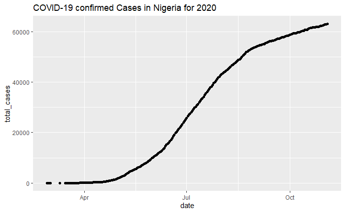

Passing Date and Prediction Variable into ds and y

Creating a new data frame for the prediction vairables

Passing the new data frame to Prophet for forecasting

```r
forcast1<-prophet(Newcovid)
```

```
Disabling yearly seasonality. Run prophet with yearly.seasonality=TRUE to override this.
Disabling daily seasonality. Run prophet with daily.seasonality=TRUE to override this.
```

Seasonality has been disabled for the above code because the data is not large enough to accomodate a whole season

i want to now create a data set predicted for the next 60 days

Lets view the new future predictions

|  | ds | trend | additive_terms | additive_terms_lower | additive_terms_upper | weekly | weekly_lower | weekly_upper | multiplicative_terms | multiplicative_terms_lower | multiplicative_terms_upper | yhat_lower | yhat_upper | trend_lower | trend_upper | yhat |
| --- | --- | --- | --- | --- | --- | --- | --- | --- | --- | --- | --- | --- | --- | --- | --- | --- |
| 280 | 2020-12-14 | 68888.44 | -4.207585 | -4.207585 | -4.207585 | -4.207585 | -4.207585 | -4.207585 | 0 | 0 | 0 | 64788.25 | 72751.28 | 64811.67 | 72799.22 | 68884.23 |
| 281 | 2020-12-15 | 69025.88 | -13.001578 | -13.001578 | -13.001578 | -13.001578 | -13.001578 | -13.001578 | 0 | 0 | 0 | 64706.21 | 73021.52 | 64760.88 | 73053.00 | 69012.88 |
| 282 | 2020-12-16 | 69163.32 | -18.540029 | -18.540029 | -18.540029 | -18.540029 | -18.540029 | -18.540029 | 0 | 0 | 0 | 64697.29 | 73329.86 | 64705.66 | 73385.64 | 69144.78 |
| 283 | 2020-12-17 | 69300.76 | -10.386754 | -10.386754 | -10.386754 | -10.386754 | -10.386754 | -10.386754 | 0 | 0 | 0 | 64689.38 | 73732.67 | 64674.33 | 73721.20 | 69290.37 |
| 284 | 2020-12-18 | 69438.19 | -1.349705 | -1.349705 | -1.349705 | -1.349705 | -1.349705 | -1.349705 | 0 | 0 | 0 | 64623.68 | 73989.19 | 64628.41 | 73996.21 | 69436.84 |
| 285 | 2020-12-19 | 69575.63 | 16.158929 | 16.158929 | 16.158929 | 16.158929 | 16.158929 | 16.158929 | 0 | 0 | 0 | 64603.28 | 74312.21 | 64579.78 | 74297.05 | 69591.79 |
| 286 | 2020-12-20 | 69713.07 | 31.326722 | 31.326722 | 31.326722 | 31.326722 | 31.326722 | 31.326722 | 0 | 0 | 0 | 64605.22 | 74621.10 | 64543.89 | 74574.25 | 69744.40 |
| 287 | 2020-12-21 | 69850.51 | -4.207585 | -4.207585 | -4.207585 | -4.207585 | -4.207585 | -4.207585 | 0 | 0 | 0 | 64450.15 | 74859.45 | 64494.58 | 74845.79 | 69846.30 |
| 288 | 2020-12-22 | 69987.95 | -13.001578 | -13.001578 | -13.001578 | -13.001578 | -13.001578 | -13.001578 | 0 | 0 | 0 | 64428.18 | 75123.73 | 64391.16 | 75158.14 | 69974.94 |
| 289 | 2020-12-23 | 70125.38 | -18.540029 | -18.540029 | -18.540029 | -18.540029 | -18.540029 | -18.540029 | 0 | 0 | 0 | 64389.32 | 75426.78 | 64348.97 | 75432.58 | 70106.84 |

[output cut: 10 more lines]

So the new predicted data have predicted corona cases till 2nd of January 2021. From Estimated and predicted data, Nigeria’s Confirmed Corona Cases by the end of the year would slightly about 70,000 cases.

lets visualize this

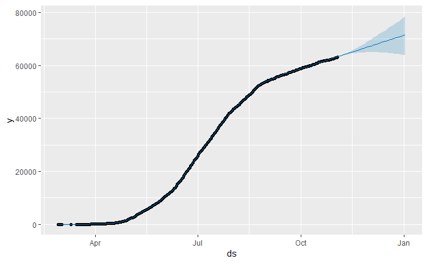

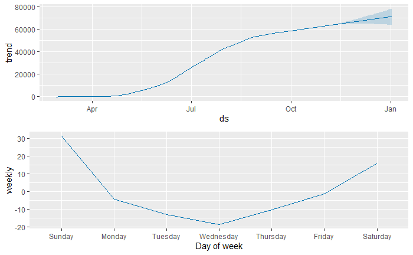

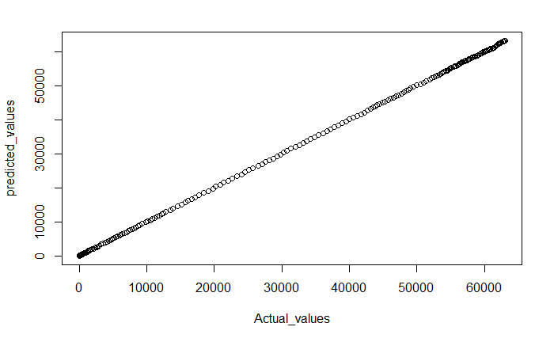